# SnowMelt Decoder — Encoder Heads Greenland 2026

## Tape- & Alufolie-Experiment

An denselben oberen Knoten wurden nacheinander zwei **optische** Manipulationen angebracht: zuerst **schwarzes Tape** (absorbiert Sonne → heizt die Stäbe), später **Alufolie** (reflektiert Sonne → kühlt sie im Sonnenlicht). Beide zeigen sich klar als Solar-Anomalie (NTC1 − Median aller Knoten) der betroffenen Knoten — mit **entgegengesetztem Vorzeichen**.

[output not shown]

¹ Die Folie wurde in der Nacht So 2026-07-12 entfernt; seither laufen die Knoten wieder unbehandelt. **Knoten 8** war nur getapt (keine Folie): im Folien-Fenster ist seine Anomalie ~0/erratisch (separates Kontakt-/Sitz-Problem) — foliert waren **Knoten 6 und 7**.

```r
BLACK_NODES <- c(6L, 7L, 8L)
ALU_NODES   <- c(6L, 7L)
win <- data.frame(
  treatment = c("Schwarztape", "Alufolie"),
  start = as.POSIXct(c("2026-07-02 22:00", "2026-07-09 20:00"), tz = "UTC"),
  end   = as.POSIXct(c("2026-07-06 00:00", "2026-07-12 22:00"), tz = "UTC"))

# Näherung Sonnenhöhe (Grad) am GRIP-Standort, ohne Paket.
solar_elev <- function(t, lat = 72.58, lon = -37.64) {
  doy  <- as.numeric(format(t, "%j", tz = "UTC"))
  hh   <- as.numeric(format(t, "%H", tz = "UTC")) + as.numeric(format(t, "%M", tz = "UTC")) / 60
  decl <- 23.45 * sin(2 * pi * (284 + doy) / 365) * pi / 180
  H    <- ((hh + lon / 15) - 12) * 15 * pi / 180; latr <- lat * pi / 180
  asin(sin(latr) * sin(decl) + cos(latr) * cos(decl) * cos(H)) * 180 / pi
}

# NTC1 pro Knoten & Zeit → Anomalie ggü. Median aller Knoten (= Umgebung).
ntc1_w  <- series_long |> filter(sensor == "ntc1_C") |> select(node, time, temp_C)
med     <- ntc1_w |> group_by(time) |>
  summarise(refT = median(temp_C, na.rm = TRUE), .groups = "drop")
anom_df <- ntc1_w |> left_join(med, by = "time") |>
  mutate(anom  = temp_C - refT,
         elev  = solar_elev(time),
         phase = factor(case_when(
           time <  win$start[1] ~ "vor",
           time <  win$end[1]   ~ "Schwarztape",
           time <  win$start[2] ~ "zwischen",
           time <  win$end[2]   ~ "Alufolie",
           TRUE                 ~ "nach"),
           levels = c("vor", "Schwarztape", "zwischen", "Alufolie", "nach")))
```

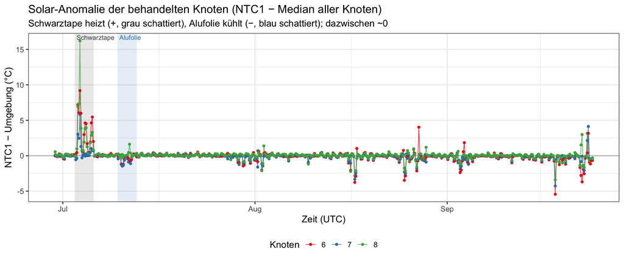

```r
treated <- anom_df |> filter(node %in% union(BLACK_NODES, ALU_NODES)) |>
  mutate(Knoten = factor(node))
ggplot(treated, aes(time, anom, colour = Knoten, group = node)) +
  annotate("rect", xmin = win$start[1], xmax = win$end[1], ymin = -Inf, ymax = Inf,
           fill = "grey30", alpha = 0.12) +
  annotate("rect", xmin = win$start[2], xmax = win$end[2], ymin = -Inf, ymax = Inf,
           fill = "#2980b9", alpha = 0.12) +
  geom_hline(yintercept = 0, colour = "grey70") +
  geom_line(alpha = 0.7) + geom_point(size = 1.3) +
  annotate("text", x = win$start[1], y = Inf, label = " Schwarztape", hjust = 0,
           vjust = 1.4, size = 3.2, colour = "grey30") +
  annotate("text", x = win$start[2], y = Inf, label = " Alufolie", hjust = 0,
           vjust = 1.4, size = 3.2, colour = "#2980b9") +
  scale_colour_brewer(palette = "Set1") +
  labs(title = "Solar-Anomalie der behandelten Knoten (NTC1 − Median aller Knoten)",
       subtitle = "Schwarztape heizt (+, grau schattiert), Alufolie kühlt (−, blau schattiert); dazwischen ~0",
       x = "Zeit (UTC)", y = "NTC1 − Umgebung (°C)") +
  theme_bw(base_size = 13) + theme(legend.position = "bottom")
```

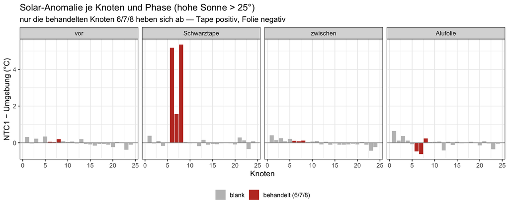

```r
phase_tab <- anom_df |>
  filter(elev > 25, phase %in% c("vor", "Schwarztape", "zwischen", "Alufolie")) |>
  group_by(node, phase) |>
  summarise(anom = mean(anom, na.rm = TRUE), .groups = "drop") |>
  mutate(behandelt = node %in% union(BLACK_NODES, ALU_NODES))
ggplot(phase_tab, aes(node, anom, fill = behandelt)) +
  geom_col() +
  geom_hline(yintercept = 0, colour = "grey60") +
  facet_wrap(~ phase, nrow = 1) +
  scale_fill_manual(values = c(`FALSE` = "grey75", `TRUE` = "#c0392b"),
                    labels = c("blank", "behandelt (6/7/8)"), name = NULL) +
  labs(title = "Solar-Anomalie je Knoten und Phase (hohe Sonne > 25°)",
       subtitle = "nur die behandelten Knoten 6/7/8 heben sich ab — Tape positiv, Folie negativ",
       x = "Knoten", y = "NTC1 − Umgebung (°C)") +
  theme_bw(base_size = 12) + theme(legend.position = "bottom")
```

```r
hs     <- anom_df |> filter(elev > 25, node %in% ALU_NODES)
ph_m   <- function(p) mean(hs$anom[hs$phase == p], na.rm = TRUE)
cat(sprintf("**Ja — deutlich sichtbar, mit umgekehrtem Vorzeichen zum Tape.** Knoten 6/7 bei hoher Sonne (>25°) im Mittel: **vor %+.2f °C**, **Schwarztape %+.2f °C**, **zwischen %+.2f °C**, **Alufolie %+.2f °C**. Die reflektierende Folie kühlt die Stäbe im Sonnenlicht (weniger absorbierte Strahlung), während das schwarze Tape sie als Schwarzkörper aufheizte. Onset der Folie exakt in der Nacht Do→Fr (erste Hochsonnen-Nachricht 07-10 10:15 bereits ≈ −1.2 °C).\n",
            ph_m("vor"), ph_m("Schwarztape"), ph_m("zwischen"), ph_m("Alufolie")))
```

**Ja — deutlich sichtbar, mit umgekehrtem Vorzeichen zum Tape.** Knoten 6/7 bei hoher Sonne (>25°) im Mittel: **vor +0.05 °C**, **Schwarztape +3.37 °C**, **zwischen +0.09 °C**, **Alufolie -0.54 °C**. Die reflektierende Folie kühlt die Stäbe im Sonnenlicht (weniger absorbierte Strahlung), während das schwarze Tape sie als Schwarzkörper aufheizte. Onset der Folie exakt in der Nacht Do→Fr (erste Hochsonnen-Nachricht 07-10 10:15 bereits ≈ −1.2 °C).

## Save result

```r
# Newest message → per-node table.
slug    <- if (use_bin) tools::file_path_sans_ext(basename(primary_file)) else paste0("imei", imei)
outfile <- sprintf("data/decoded_%s_%s.csv", slug, format(time_utc, "%Y%m%d_%H%M%S"))
write.csv(nodes, outfile, row.names = FALSE)
cat("Saved:", outfile, "\n")
```

```
Saved: data/decoded_300434065508020-rb2609241015_20260924_101557.csv
```

```r
# Whole time series → one long CSV (time, node, sensor, temp_C).
if (exists("multi") && multi) {
  ts_file <- sprintf("data/series_imei%s_%s.csv", imei, format(time_utc, "%Y%m%d_%H%M%S"))
  write.csv(series_long, ts_file, row.names = FALSE)
  cat("Saved series:", ts_file, "\n")
}
```

```
Saved series: data/series_imei300434065508020_20260924_101557.csv
```